# *Netflix Titles Dataset*

## *Problem Statement*

Netflix is one of the largest OTT platform and it is operating in many countries. And New contents are added day by day. In the Exploratory data analysis , we have analysed the dataset , and the Data analysis will help to learn how Netflix is successful in content release and types of contents mostly released , top genre content, who are top actors among all, which country reeased the highest number of content on Netflix.

## *Dataset Link*

https://www.kaggle.com/datasets/victorsoeiro/netflix-tv-shows-and-movies

### **Description**

This dataset consists of listing of all the movies and Tv shows available on Netflix along with details such as cast, directors, ratings, release year, a Unique Id for movie/tv show, country where the movie/tv show was produced, date Tv show/movie was added on Netflix and total duration, etc. This dataset analysis helps you find the most popular and best rated Tv shows and movies according to different contents available in different countries. And in this dataset, we will analyze what Netflix users prefer more- Tv shows or movies.

### **Objective**

1. We will visualize the proportion of Netflix content by type (Movie/Tv shows).
2. We will visualize the Top 15 Countries by Amount of content they have released.
3. We will visualize the Top 10 actors.
4. We will visualize the distribution of Netflix content by rating classes.
5. We will visualize in which years highest number of content released.
6. We will also visualize which genre mostly released on netflix platform.

```python
from google.colab import drive
drive.mount('/content/drive/')
import os
os.chdir('/content/drive/My Drive/dav')
```

```python
import pandas as pd
import numpy as np
df=pd.read_csv('netflix_titles.csv')
print(df)
```

```
       show_id     type                                        title  \
0     81145628    Movie      Norm of the North: King Sized Adventure
1     80117401    Movie                   Jandino: Whatever it Takes
2     70234439  TV Show                           Transformers Prime
3     80058654  TV Show             Transformers: Robots in Disguise
4     80125979    Movie                                 #realityhigh
...        ...      ...                                          ...
6229  80000063  TV Show                                 Red vs. Blue
6230  70286564  TV Show                                        Maron
6231  80116008    Movie       Little Baby Bum: Nursery Rhyme Friends
6232  70281022  TV Show  A Young Doctor's Notebook and Other Stories
6233  70153404  TV Show                                      Friends

                      director  \
0     Richard Finn, Tim Maltby
```

[output cut: 77 more lines]

```python
df.describe()
```

|  | show_id | release_year |
| --- | --- | --- |
| count | 6.234000e+03 | 6234.00000 |
| mean | 7.670368e+07 | 2013.35932 |
| std | 1.094296e+07 | 8.81162 |
| min | 2.477470e+05 | 1925.00000 |
| 25% | 8.003580e+07 | 2013.00000 |
| 50% | 8.016337e+07 | 2016.00000 |
| 75% | 8.024489e+07 | 2018.00000 |
| max | 8.123573e+07 | 2020.00000 |

## *Dataset Pre-processing*

```python
df.isna()
```

|  | show_id | type | title | director | cast | country | date_added | release_year | rating | duration | listed_in | description |
| --- | --- | --- | --- | --- | --- | --- | --- | --- | --- | --- | --- | --- |
| 0 | False | False | False | False | False | False | False | False | False | False | False | False |
| 1 | False | False | False | True | False | False | False | False | False | False | False | False |
| 2 | False | False | False | True | False | False | False | False | False | False | False | False |
| 3 | False | False | False | True | False | False | False | False | False | False | False | False |
| 4 | False | False | False | False | False | False | False | False | False | False | False | False |
| ... | ... | ... | ... | ... | ... | ... | ... | ... | ... | ... | ... | ... |
| 6229 | False | False | False | True | False | False | True | False | False | False | False | False |
| 6230 | False | False | False | True | False | False | True | False | False | False | False | False |
| 6231 | False | False | False | True | True | True | True | False | True | False | False | False |
| 6232 | False | False | False | True | False | False | True | False | False | False | False | False |
| 6233 | False | False | False | True | False | False | True | False | False | False | False | False |

6234 rows × 12 columns

```python
df.isnull().sum()
```

```
show_id            0
type               0
title              0
director        1969
cast             570
country          476
date_added        11
release_year       0
rating            10
duration           0
listed_in          0
description        0
dtype: int64
```

```python
df.duplicated().sum()
```

```
0
```

```python
df.columns
```

```
Index(['show_id', 'type', 'title', 'director', 'cast', 'country', 'date_added',
       'release_year', 'rating', 'duration', 'listed_in', 'description'],
      dtype='object')
```

```python
df.dtypes
df.dtypes.value_counts()
```

```
object    10
int64      2
dtype: int64
```

```python
df.dropna(inplace=True)
print(df.isnull().sum())
```

```
show_id         0
type            0
title           0
director        0
cast            0
country         0
date_added      0
release_year    0
rating          0
duration        0
listed_in       0
description     0
dtype: int64
```

## *Univarient Analysis*

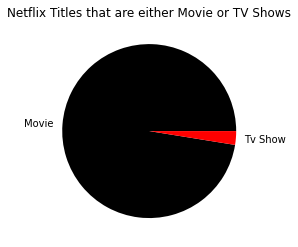

```python
# type(movie/tv show) mostly released on Netflix
import matplotlib.pyplot as plt
import seaborn as sns
plt.title("Netflix Titles that are either Movie or TV Shows")
mylabels=["Movie","Tv Show"]
g=plt.pie(df.type.value_counts(), labels=mylabels ,colors=['black','red'])
plt.show()
```

Observation:- Looking at above chart, we can say Netflix has more movies than the number of TV shows.

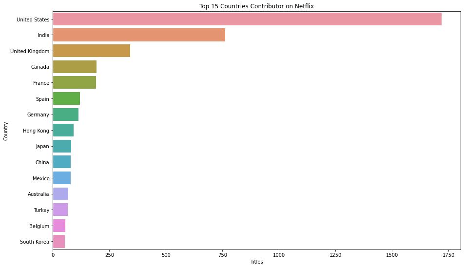

```python
# Which countries released highest number of content on Netflix
countries = df.set_index('title').country.str.split(', ', expand=True).stack()
plt.figure(figsize=(15,9))
g = sns.countplot(y = countries, order=countries.value_counts().index[:15])
plt.title("Top 15 Countries Contributor on Netflix")
plt.xlabel("Titles")
plt.ylabel("Country")
plt.show()
```

From above graph can see that United states produces more content

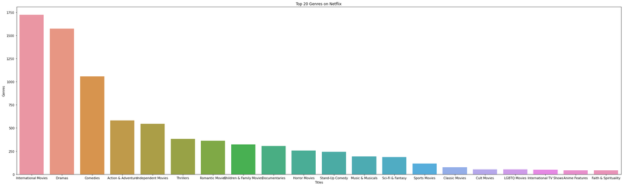

```python
#Top Genres on Netflix
genres = df.set_index('title').listed_in.str.split(', ', expand=True).stack()
plt.figure(figsize=(35,10))
g = sns.countplot(x= genres, order=genres.value_counts().index[:20])
plt.title('Top 20 Genres on Netflix')
plt.xlabel('Titles')
plt.ylabel('Genres')
plt.show()
```

from above graph we can see the most liked genres are 'International Movies','Dramas'

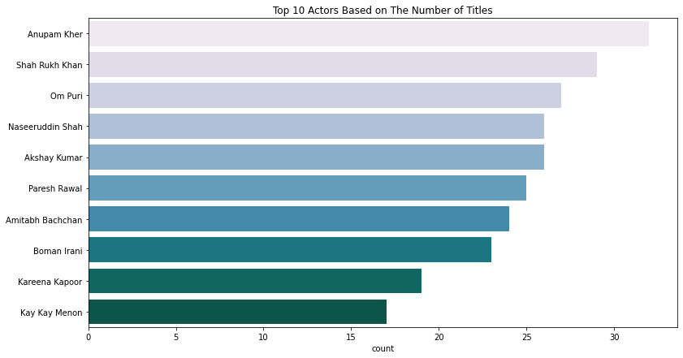

```python
#Top Actors on Netflix
cast_shows = df.set_index('title').cast.str.split(', ', expand=True).stack()
plt.figure(figsize=(13,7))
plt.title("Top 10 Actors Based on The Number of Titles")
sns.countplot(y = cast_shows, order=cast_shows.value_counts().index[:10], palette='PuBuGn')
plt.show()
```

from above graph we can see the most liked actors are 'Anupam Kher','Shah Rukh Khan'

```python
#Distribution of Content Ratings on Netflix
import plotly.express as px
z = df.groupby('rating').size().reset_index(name='counts')
pieChart = px.pie(z, values='counts', names='rating', title='Distribution of Content Ratings on Netflix')
pieChart.show()
```

[interactive chart not shown]

From above Pie Chart we can see distribution of Content Ratings on Netflix

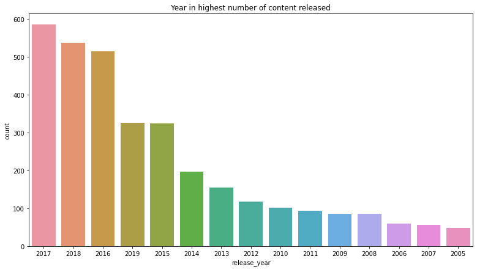

```python
#In which year highest number of content release
yr = df.set_index('title').release_year
plt.figure(figsize=(13,7))
plt.title("Year in highest number of content released")
sns.countplot(x = yr, order=yr.value_counts().index[:15])
plt.show()
```

From above bar graph we can see highest content release in 2017

## *Bivarient Analysis*

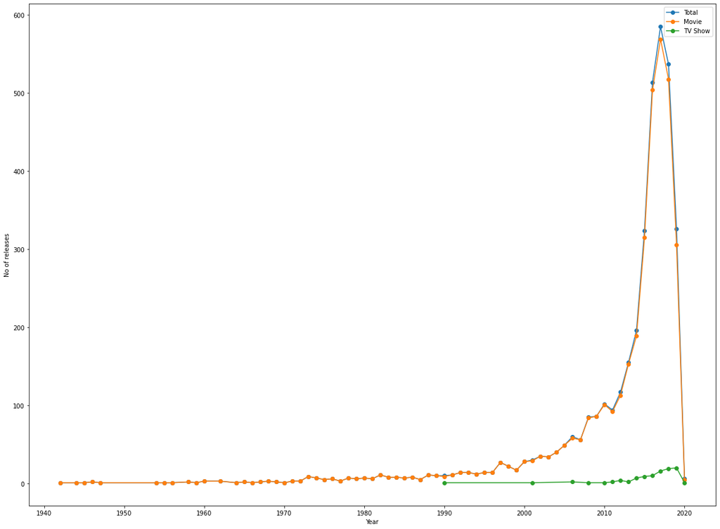

```python
#Content released per year
xy = df['release_year'].value_counts().sort_index()
xy1 = df[df['type']=='Movie']['release_year'].value_counts().sort_index()
xy2 = df[df['type']=='TV Show']['release_year'].value_counts().sort_index()

plt.figure(figsize=(20,15))
plt.plot(xy.index,xy.values,marker='o',label='Total')
plt.plot(xy1.index,xy1.values,marker='o',label='Movie')
plt.plot(xy2.index,xy2.values,marker='o',label='TV Show')
plt.xlabel("Year")
plt.ylabel("No of releases")
plt.legend()
plt.show()
```

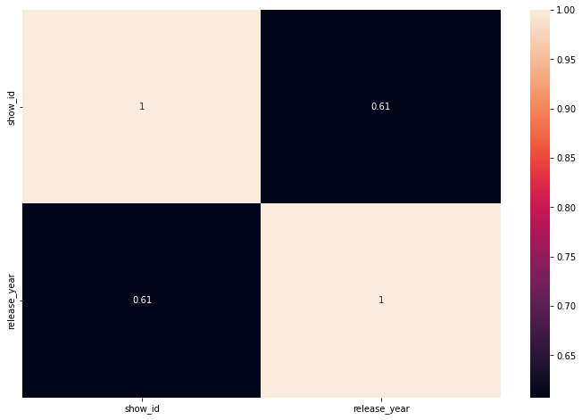

```python
import matplotlib.pyplot as plt
plt.figure(figsize=(12, 8))

vg_corr = df.corr()
sns.heatmap(vg_corr,
            xticklabels = vg_corr.columns.values,
            yticklabels = vg_corr.columns.values,annot=True);
```

From above heap map we can see corelation between differnet columns

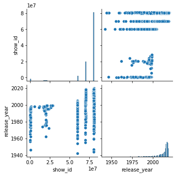

```python
import seaborn as sns
plt.figure(figsize=(20, 20))

sns.pairplot(df)
```

```python
#different titles of Movies/TV Shows in different Year
px.scatter(df,x='title',y='release_year')
```

[interactive chart not shown]

From above graph we can see different titles of Movies/TV Shows release in different year